# Week 03

Data wrangling pt. 1

### Thursday announcements

- Quiz 01 to start class today
- Then Lab 03 in groups (see Brightspace)
- Week 04 lecture posted - shorter this week!
- One week from today: [project brainstorm due](https://nova-stat-4380.netlify.app/project/#choosing-a-topic-project-brainstorm)

### Statistician(s) of the Week

[Edna Paisano](https://hardin47.github.io/CURV/scholars/paisano.html)

[Desi Small-Rodriguez](https://hardin47.github.io/CURV/scholars/small-rodriguez.html)

### Announcements

- Lab 02 optional (full credit if you turn it in completed, exempt if you don’t)
- Annotations due Thursday
- First quiz in class Thursday - will focus on Week 01 & 02 (basics + data viz, not new data wrangling stuff yet)

### Questions?

*What’s the difference between the `fill` and `color` aesthetics in `ggplot`?*

- For histograms / things with bars, `color` = outside, `fill` = inside.

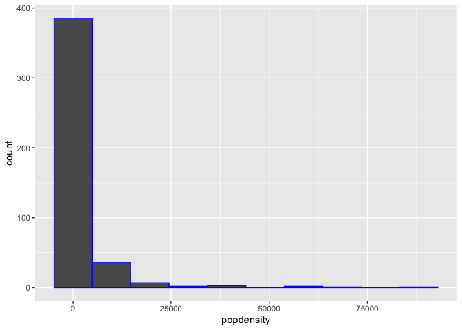

```r
ggplot(midwest, aes(x = popdensity)) +
  geom_histogram(bins = 10, color = "blue")
```

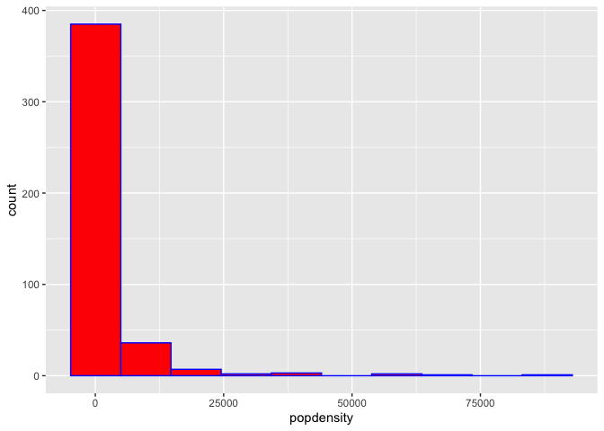

```r
ggplot(midwest, aes(x = popdensity)) +
  geom_histogram(bins = 10, color = "blue", fill = "red")
```

- For points, use `color`

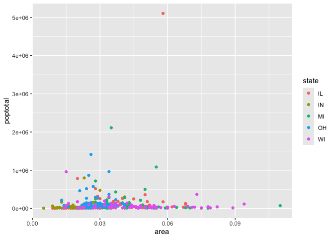

```r
ggplot(midwest, aes(x = area, y = poptotal,
                    color = state)) +
  geom_point()
```

- Put inside `aes()` if you want to map a variable in the data to the color/fill
- Put outside `aes()`, usually in the `geom_` layer, if you want to set `color/fill` to a specific color for the whole plot
- Later layers will override earlier layers

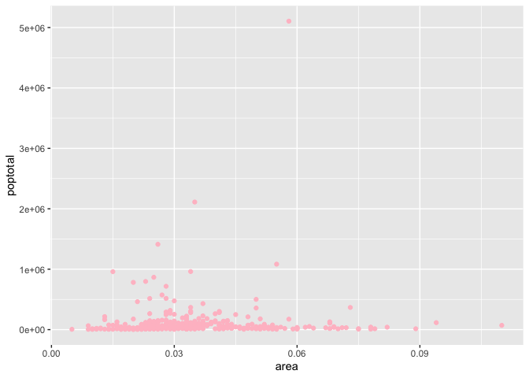

```r
ggplot(midwest, aes(x = area, y = poptotal,
                    color = state)) +
  geom_point(color = "pink")
```

### Application Exercise

- The remainder of class will be spent on AE-03.
- You can access it from GitHub.
- It is due at the end of class today.
- To turn it in, you should upload your .html file to Brightspace.